# Flipkart Product Price & Discount Analysis

## 1. Business Problem

Flipkart (and any large e-commerce marketplace) lists millions of products across hundreds of categories, each priced and discounted independently by sellers. Without a data-driven view of pricing behaviour, the business risks two costly mistakes:

- **Over-discounting** categories that don't need it, eroding margin.
- **Under-discounting** categories where competitive pricing actually drives conversion.

**As a Data Analyst, the objective of this project is to answer:**

1. Which categories dominate the catalog, and which are under/over-represented?
2. How much discount is actually being given, and does it vary meaningfully by category?
3. Is there a relationship between a product's price and the discount it receives?
4. Which categories and brands carry the most "listed value" on the platform?
5. What pricing tier does the bulk of the catalog sit in — and what does that imply for the business?

The output is a set of **data-backed pricing and category recommendations**, not just charts.

## 2. Setup & Data Loading

```python
import pandas as pd
import numpy as np
import matplotlib.pyplot as plt
import seaborn as sns

pd.set_option('display.max_columns', None)
plt.rcParams['figure.dpi'] = 110
sns.set_style('whitegrid')
sns.set_palette(['#2563EB','#F59E0B','#10B981','#EF4444','#8B5CF6','#06B6D4'])

df_raw = pd.read_csv('data/flipkart_full_clean.csv')
print("Shape:", df_raw.shape)
df_raw.head(3)
```

```
Shape: (9998, 18)
```

|  | uniq_id | crawl_timestamp | product_url | product_name | product_category_tree | pid | retail_price | discounted_price | image | is_FK_Advantage_product | description | product_rating | overall_rating | brand | product_specifications | main_category | discount_amount | discount_percent |
| --- | --- | --- | --- | --- | --- | --- | --- | --- | --- | --- | --- | --- | --- | --- | --- | --- | --- | --- |
| 0 | c2d766ca982eca8304150849735ffef9 | 2016-03-25 22:59:23 +0000 | http://www.flipkart.com/alisha-solid-women-s-c... | Alisha Solid Women's Cycling Shorts | ["Clothing >> Women's Clothing >> Lingerie, Sl... | SRTEH2FF9KEDEFGF | 999.0 | 379.0 | ["http://img5a.flixcart.com/image/short/u/4/a/... | False | Key Features of Alisha Solid Women's Cycling S... | NaN | NaN | Alisha | {"product_specification"=>[{"key"=>"Number of ... | Clothing | 620.0 | 62.06 |
| 1 | 7f7036a6d550aaa89d34c77bd39a5e48 | 2016-03-25 22:59:23 +0000 | http://www.flipkart.com/fabhomedecor-fabric-do... | FabHomeDecor Fabric Double Sofa Bed | ["Furniture >> Living Room Furniture >> Sofa B... | SBEEH3QGU7MFYJFY | 32157.0 | 22646.0 | ["http://img6a.flixcart.com/image/sofa-bed/j/f... | False | FabHomeDecor Fabric Double Sofa Bed (Finish Co... | NaN | NaN | FabHomeDecor | {"product_specification"=>[{"key"=>"Installati... | Furniture | 9511.0 | 29.58 |
| 2 | f449ec65dcbc041b6ae5e6a32717d01b | 2016-03-25 22:59:23 +0000 | http://www.flipkart.com/aw-bellies/p/itmeh4grg... | AW Bellies | ["Footwear >> Women's Footwear >> Ballerinas >... | SHOEH4GRSUBJGZXE | 999.0 | 499.0 | ["http://img5a.flixcart.com/image/shoe/7/z/z/r... | False | Key Features of AW Bellies Sandals Wedges Heel... | NaN | NaN | AW | {"product_specification"=>[{"key"=>"Ideal For"... | Footwear | 500.0 | 50.05 |

**Note on source file:** the raw Kaggle export (`flipkart_com-ecommerce_sample.csv`) contains ~19,983 crawl rows, of which roughly half are blank filler rows introduced during the original export. These were removed first (`dropna(how='all')`), leaving **9,998 genuine product records** — the file loaded above (`flipkart_full_clean.csv`) already reflects that first cleaning pass.

## 3. Data Cleaning & Feature Engineering

Raw fields aren't analysis-ready. Three problems need fixing before any pricing analysis is trustworthy:

```python
# Check missing values
df_raw.isnull().sum()
```

```
uniq_id                       0
crawl_timestamp               0
product_url                   0
product_name                  0
product_category_tree         0
pid                           0
retail_price                 33
discounted_price             33
image                         3
is_FK_Advantage_product       0
description                   1
product_rating             9027
overall_rating             9027
brand                         0
product_specifications        6
main_category                 0
discount_amount              33
discount_percent             33
dtype: int64
```

```python
def get_top_category(tree):
    if pd.isna(tree):
        return np.nan
    s = str(tree).strip('[]"')
    return s.split(' >> ')[0].strip().replace('"', '')

df = df_raw.copy()
df['main_category'] = df['product_category_tree'].apply(get_top_category)

# Discount metrics
df['discount_amount']  = df['retail_price'] - df['discounted_price']
df['discount_percent'] = ((df['discount_amount'] / df['retail_price']) * 100).round(2)

# Brand cleanup
df['brand'] = df['brand'].fillna('Unknown')

# Keep only rows with valid, usable price data
df = df.dropna(subset=['retail_price', 'discounted_price'])
df = df[df['retail_price'] > 0]

print("Final analyzable dataset:", df.shape)
df[['product_name','main_category','retail_price','discounted_price','discount_percent','brand']].head()
```

```
Final analyzable dataset: (9965, 18)
```

|  | product_name | main_category | retail_price | discounted_price | discount_percent | brand |
| --- | --- | --- | --- | --- | --- | --- |
| 0 | Alisha Solid Women's Cycling Shorts | Clothing | 999.0 | 379.0 | 62.06 | Alisha |
| 1 | FabHomeDecor Fabric Double Sofa Bed | Furniture | 32157.0 | 22646.0 | 29.58 | FabHomeDecor |
| 2 | AW Bellies | Footwear | 999.0 | 499.0 | 50.05 | AW |
| 3 | Alisha Solid Women's Cycling Shorts | Clothing | 699.0 | 267.0 | 61.80 | Alisha |
| 4 | Sicons All Purpose Arnica Dog Shampoo | Pet Supplies | 220.0 | 210.0 | 4.55 | Sicons |

```python
# Price segment bucketing — useful for understanding where the catalog sits
def price_bucket(p):
    if p < 500: return 'Under ₹500'
    elif p < 1500: return '₹500 – ₹1,500'
    elif p < 5000: return '₹1,500 – ₹5,000'
    elif p < 15000: return '₹5,000 – ₹15,000'
    else: return 'Above ₹15,000'

df['price_bucket'] = df['discounted_price'].apply(price_bucket)
df.to_csv('data/flipkart_priced_clean.csv', index=False)
df.describe()[['retail_price','discounted_price','discount_percent']]
```

|  | retail_price | discounted_price | discount_percent |
| --- | --- | --- | --- |
| count | 9965.000000 | 9965.000000 | 9965.000000 |
| mean | 2319.612544 | 1496.012444 | 40.702878 |
| std | 8005.328681 | 7318.258534 | 24.115282 |
| min | 36.000000 | 36.000000 | 0.000000 |
| 25% | 599.000000 | 300.000000 | 20.050000 |
| 50% | 999.000000 | 499.000000 | 47.090000 |
| 75% | 1797.000000 | 989.000000 | 60.070000 |
| max | 571230.000000 | 571230.000000 | 95.270000 |

## 4. Exploratory Data Analysis

### 4.1 Which categories dominate the catalog?

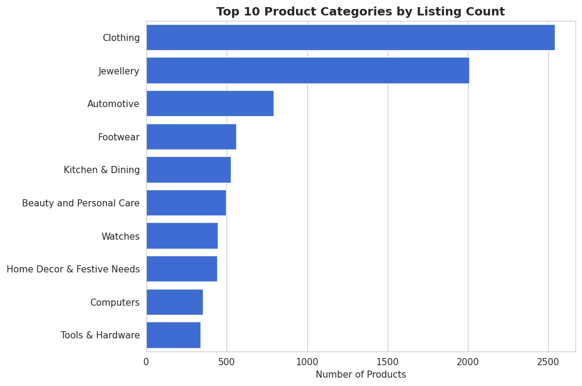

```
main_category
Clothing                      2543
Jewellery                     2011
Automotive                     794
Footwear                       562
Kitchen & Dining               527
Beauty and Personal Care       497
Watches                        447
Home Decor & Festive Needs     442
Computers                      353
Tools & Hardware               341
Name: count, dtype: int64
```

```python
top_cat = df['main_category'].value_counts().head(10)

plt.figure(figsize=(9,6))
sns.barplot(x=top_cat.values, y=top_cat.index, color='#2563EB')
plt.title('Top 10 Product Categories by Listing Count', fontsize=13, fontweight='bold')
plt.xlabel('Number of Products'); plt.ylabel('')
plt.tight_layout()
plt.savefig('charts/01_top_categories.png')
plt.show()

top_cat
```

**Reading:** `Clothing` (2,543 listings) and `Jewellery` (2,011 listings) together make up roughly **46% of the entire catalog** on their own. Everything after `Automotive` (794) drops off sharply — the catalog is heavily concentrated in a handful of categories, not evenly spread.

### 4.2 How much discount does each category actually give?

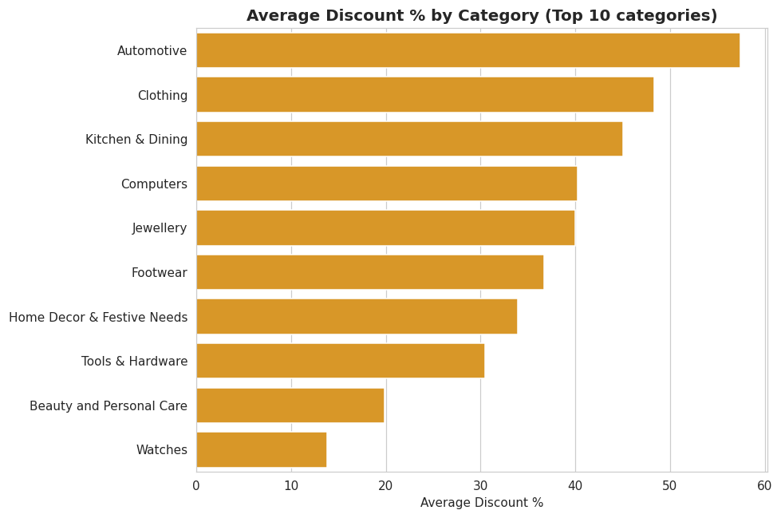

```
main_category
Automotive                    57.449496
Clothing                      48.288183
Kitchen & Dining              45.027590
Computers                     40.233399
Jewellery                     40.002660
Footwear                      36.674235
Home Decor & Festive Needs    33.966991
Tools & Hardware              30.464545
Beauty and Personal Care      19.824829
Watches                       13.826018
Name: discount_percent, dtype: float64
```

```python
avg_disc = (df[df['main_category'].isin(top_cat.index)]
            .groupby('main_category')['discount_percent']
            .mean().sort_values(ascending=False))

plt.figure(figsize=(9,6))
sns.barplot(x=avg_disc.values, y=avg_disc.index, color='#F59E0B')
plt.title('Average Discount % by Category (Top 10 categories)', fontsize=13, fontweight='bold')
plt.xlabel('Average Discount %'); plt.ylabel('')
plt.tight_layout()
plt.savefig('charts/02_avg_discount_by_category.png')
plt.show()

avg_disc
```

### 4.3 Retail Price vs Discounted Price — overall distribution

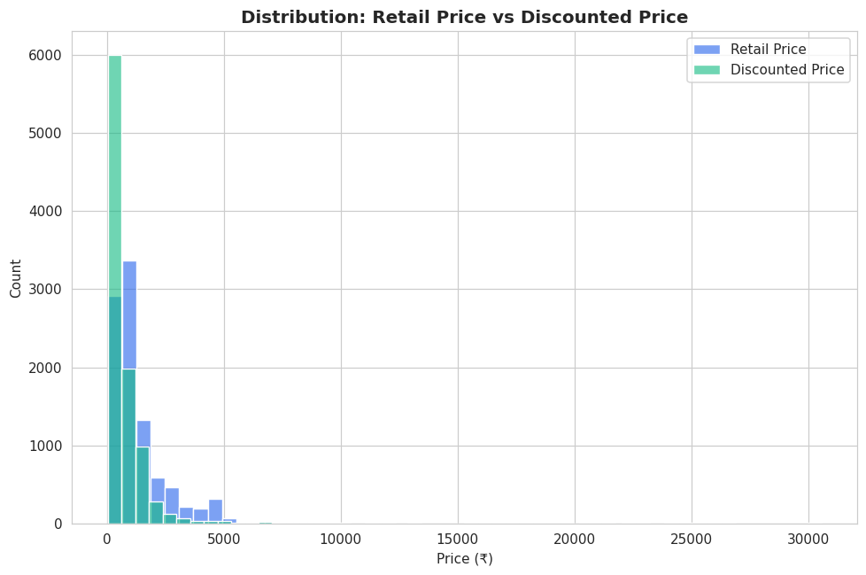

```python
cap = df['retail_price'].quantile(0.99)   # trim extreme luxury outliers just for the plot
df_viz = df[df['retail_price'] <= cap]

plt.figure(figsize=(9,6))
sns.histplot(df_viz['retail_price'], bins=50, color='#2563EB', label='Retail Price', alpha=0.6)
sns.histplot(df_viz['discounted_price'], bins=50, color='#10B981', label='Discounted Price', alpha=0.6)
plt.title('Distribution: Retail Price vs Discounted Price', fontsize=13, fontweight='bold')
plt.xlabel('Price (₹)'); plt.legend()
plt.tight_layout()
plt.savefig('charts/03_price_distribution.png')
plt.show()
```

**Reading:** Both distributions are heavily right-skewed — most products are priced under ₹2,000, with a long tail of premium/luxury items pulling the mean up. The discounted-price curve sits visibly to the left of retail price, confirming discounting is happening across almost the entire catalog, not just at the high end.

### 4.4 How is discount percentage distributed across all products?

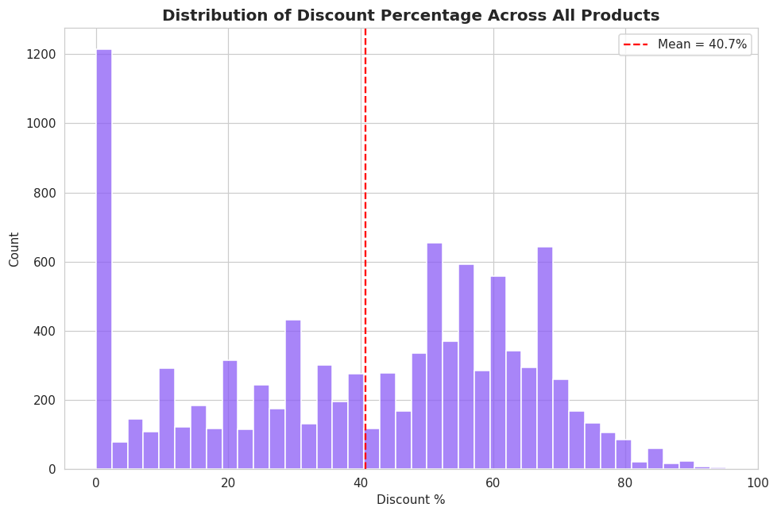

```
Mean discount: 40.7 %
Median discount: 47.09 %
```

```python
plt.figure(figsize=(9,6))
sns.histplot(df['discount_percent'], bins=40, color='#8B5CF6')
plt.axvline(df['discount_percent'].mean(), color='red', linestyle='--',
            label=f"Mean = {df['discount_percent'].mean():.1f}%")
plt.title('Distribution of Discount Percentage Across All Products', fontsize=13, fontweight='bold')
plt.xlabel('Discount %'); plt.legend()
plt.tight_layout()
plt.savefig('charts/04_discount_distribution.png')
plt.show()

print("Mean discount:", round(df['discount_percent'].mean(),2), "%")
print("Median discount:", round(df['discount_percent'].median(),2), "%")
```

**Reading:** Average discount across the catalog is **40.7%**, with a median of **47.1%** — the median being higher than the mean tells us a large cluster of products sit at very high discounts (60–70%+), while a smaller group of premium/branded items barely gets discounted at all, pulling the mean down.

### 4.5 Does a higher retail price mean a bigger discount?

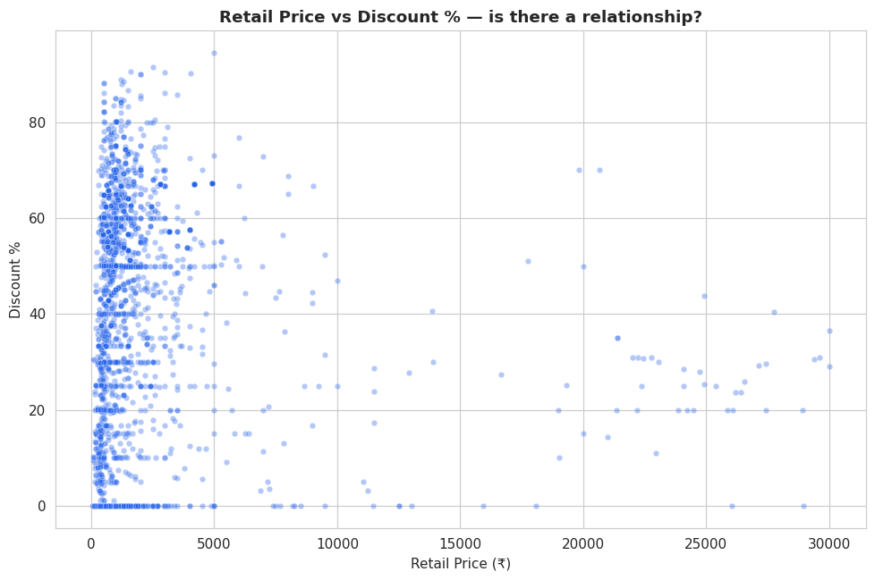

```
Correlation (retail price vs discount %): -0.062
```

```python
sample = df_viz.sample(min(2500, len(df_viz)), random_state=42)

plt.figure(figsize=(9,6))
sns.scatterplot(data=sample, x='retail_price', y='discount_percent', alpha=0.35, color='#2563EB', s=18)
plt.title('Retail Price vs Discount % — is there a relationship?', fontsize=12, fontweight='bold')
plt.xlabel('Retail Price (₹)'); plt.ylabel('Discount %')
plt.tight_layout()
plt.savefig('charts/05_price_vs_discount.png')
plt.show()

corr = df[['retail_price','discount_percent']].corr().iloc[0,1]
print("Correlation (retail price vs discount %):", round(corr,3))
```

**Reading:** The correlation is essentially **zero (−0.06)** — there is no meaningful relationship between how expensive a product is and how much discount it gets. This is an important finding: **discounting decisions on the platform appear to be driven by category/seller strategy, not by price tier**, which is exactly the kind of insight that should inform a more deliberate, price-aware discounting policy.

### 4.6 Which brands carry the highest average selling price?

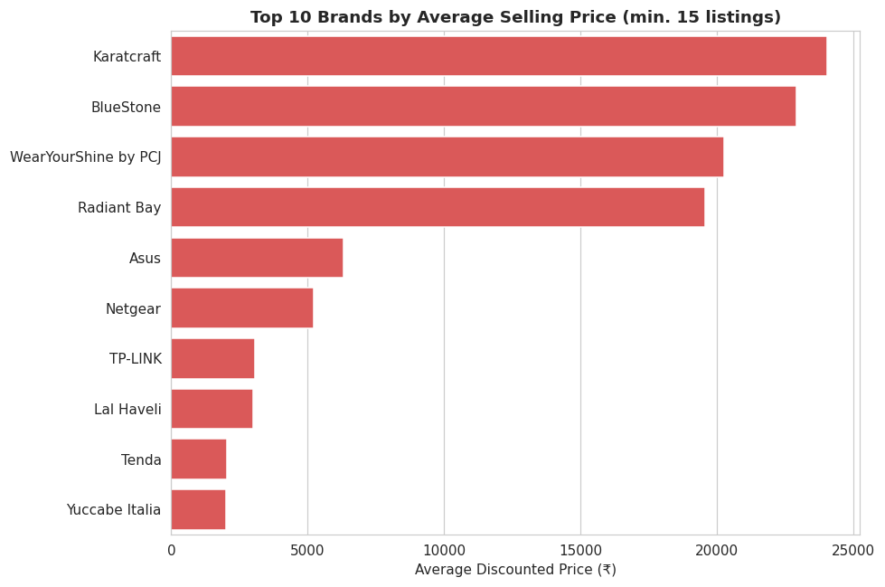

```
brand
Karatcraft              24043.760417
BlueStone               22903.882353
WearYourShine by PCJ    20256.000000
Radiant Bay             19571.547619
Asus                     6301.047619
Netgear                  5204.875000
TP-LINK                  3076.142857
Lal Haveli               2992.090909
Tenda                    2043.285714
Yuccabe Italia           2001.962963
Name: discounted_price, dtype: float64
```

```python
brand_counts = df['brand'].value_counts()
valid_brands = brand_counts[(brand_counts >= 15) & (brand_counts.index != 'Unknown')].index
brand_price = (df[df['brand'].isin(valid_brands)]
               .groupby('brand')['discounted_price']
               .mean().sort_values(ascending=False).head(10))

plt.figure(figsize=(9,6))
sns.barplot(x=brand_price.values, y=brand_price.index, color='#EF4444')
plt.title('Top 10 Brands by Average Selling Price (min. 15 listings)', fontsize=12, fontweight='bold')
plt.xlabel('Average Discounted Price (₹)'); plt.ylabel('')
plt.tight_layout()
plt.savefig('charts/06_top_brands_price.png')
plt.show()

brand_price
```

### 4.7 Which categories hold the most total listed value?

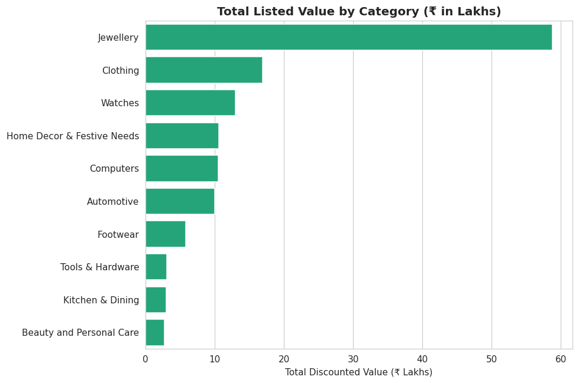

```
main_category
Jewellery                     5873924.0
Clothing                      1686045.0
Watches                       1299553.0
Home Decor & Festive Needs    1054057.0
Computers                     1048549.0
Automotive                    1000604.0
Footwear                       577585.0
Tools & Hardware               309852.0
Kitchen & Dining               294472.0
Beauty and Personal Care       273303.0
Name: discounted_price, dtype: float64
```

```python
cat_value = (df[df['main_category'].isin(top_cat.index)]
             .groupby('main_category')['discounted_price']
             .sum().sort_values(ascending=False))

plt.figure(figsize=(9,6))
sns.barplot(x=cat_value.values/1e5, y=cat_value.index, color='#10B981')
plt.title('Total Listed Value by Category (₹ in Lakhs)', fontsize=13, fontweight='bold')
plt.xlabel('Total Discounted Value (₹ Lakhs)'); plt.ylabel('')
plt.tight_layout()
plt.savefig('charts/07_category_value.png')
plt.show()

cat_value
```

### 4.8 Where does the catalog sit price-wise?

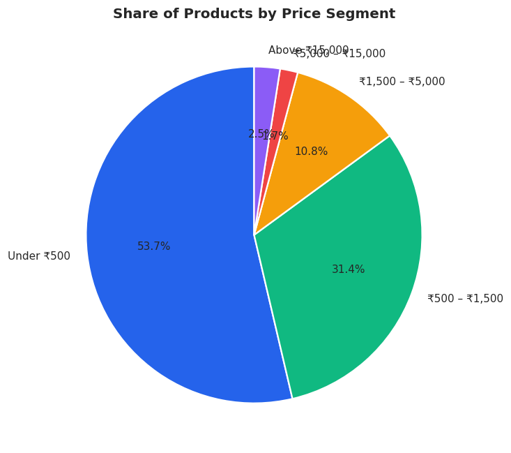

```
price_bucket
Under ₹500          5348
₹500 – ₹1,500       3127
₹1,500 – ₹5,000     1073
₹5,000 – ₹15,000     170
Above ₹15,000        247
Name: count, dtype: int64
```

```python
order = ['Under ₹500','₹500 – ₹1,500','₹1,500 – ₹5,000','₹5,000 – ₹15,000','Above ₹15,000']
bucket_counts = df['price_bucket'].value_counts().reindex(order)

plt.figure(figsize=(8,6))
colors = ['#2563EB','#10B981','#F59E0B','#EF4444','#8B5CF6']
plt.pie(bucket_counts.values, labels=bucket_counts.index, autopct='%1.1f%%',
        colors=colors, startangle=90, wedgeprops={'edgecolor':'white','linewidth':1.5})
plt.title('Share of Products by Price Segment', fontsize=13, fontweight='bold')
plt.tight_layout()
plt.savefig('charts/08_price_segments.png')
plt.show()

bucket_counts
```

## 5. Key Business Insights & Recommendations

[output not shown]

## 6. Conclusion

This analysis turned a 10,000-row raw product crawl into a set of concrete pricing and category decisions: where the catalog's volume sits, where its *value* sits (not the same categories), how inconsistent discounting is across categories, and the (surprising) lack of a price–discount relationship platform-wide.

**Next steps if this were a live business project:** join this against actual sales/conversion data to see whether the high-discount categories (`Automotive`, `Clothing`) are actually converting better than low-discount ones (`Watches`) — that would tell us whether the current discount strategy is *working*, not just whether it *exists*.

*Dataset: [Flipkart Products Dataset, PromptCloud — Kaggle](https://www.kaggle.com/datasets/PromptCloudHQ/flipkart-products) · Analysis by Ashray Bhasin*